# ‘SEQUENTIAL TRAINING UPDATES - LM MODELS’

Stanley Sayianka

3/13/2021

Now we turn to linear regression to experiment our model, Here i will use the real estate dataset, which contains prices of houses, together with other variables, which we’d like to know whether they affect the price of the house, e.g. the house age, distance to nearest M.R.T station, latitude, longitude(and probably altitude).

I will not display the initial visualizations, and the data preprocessing that much, so that we could just go straight to the point.

## LOADING DATA

```r
# directory
setwd("C:/Users/stanley/Desktop/MISCELLANEOUS R/ml projects/regression/real estate regression analysis")

# libraries
require(pacman)
```

```r
p_load(readxl, dplyr, ggplot2, magrittr,
       plotly, gganimate, ModelMetrics, stringr,
       raster, sp)

# data
dd <- read_excel("Real estate valuation full data.xlsx", sheet=1) %>%
  as.data.frame()

head(dd)
```

```
##   X1 transaction date X2 house age X3 distance to the nearest MRT station
## 1            2012.917         32.0                               84.87882
## 2            2012.917         19.5                              306.59470
## 3            2013.583         13.3                              561.98450
## 4            2013.500         13.3                              561.98450
## 5            2012.833          5.0                              390.56840
## 6            2012.667          7.1                             2175.03000
##   X4 number of convenience stores X5 latitude X6 longitude
## 1                              10    24.98298     121.5402
## 2                               9    24.98034     121.5395
## 3                               5    24.98746     121.5439
## 4                               5    24.98746     121.5439
## 5                               5    24.97937     121.5425
## 6                               3    24.96305     121.5125
##   Y house price of unit area
## 1                       37.9
## 2                       42.2
## 3                       47.3
## 4                       54.8
## 5                       43.1
## 6                       32.1
```

```r
glimpse(dd)
```

```
## Rows: 414
## Columns: 7
## $ `X1 transaction date`                    <dbl> 2012.917, 2012.917, 2013.5...
## $ `X2 house age`                           <dbl> 32.0, 19.5, 13.3, 13.3, 5....
## $ `X3 distance to the nearest MRT station` <dbl> 84.87882, 306.59470, 561.9...
## $ `X4 number of convenience stores`        <dbl> 10, 9, 5, 5, 5, 3, 7, 6, 1...
## $ `X5 latitude`                            <dbl> 24.98298, 24.98034, 24.987...
## $ `X6 longitude`                           <dbl> 121.5402, 121.5395, 121.54...
## $ `Y house price of unit area`             <dbl> 37.9, 42.2, 47.3, 54.8, 43...
```

I thought it would seem great to fetch altitude data, in order to see whether altitude of a place affects the house prices therein, because latitude and longitude really have no meaning when looking for houses(unless of course the equator)

```r
# generating altitude data ------------------------------------------------

altitude_data <- dplyr::select(dd, `X6 longitude`, `X5 latitude`)
altitude_data <- data.frame(cbind(dd$`X6 longitude`, dd$`X5 latitude`))

names(altitude_data) <- c("lon", "lat")

# using raster
x <- getData('alt', country = "TW")

full_alt <- cbind(altitude_data, alt = extract(x, altitude_data))


alt_dd <- cbind(dd, full_alt$alt)
names(alt_dd) <- c(names(dd), "altitude")
```

Now, i can try fitting the regression model, as shown below: I will omit all the models i tried fitting, and just show you the best model i came up with(You can’t believe altitude was insignificant to the house prices !).

```r
# start of model analysis -------------------------------------------------

# selecting variables of interest
newdd <- dplyr::select(dd,
                `X2 house age`,
                `X3 distance to the nearest MRT station`,
                `X4 number of convenience stores`,
                `X5 latitude`,`X6 longitude`,
                `Y house price of unit area`)

# splitting data into test and train

# just choosing sequentially
newdd_train <- newdd[1:314, ]
newdd_test <- newdd[315:414, ]

# fitting linear regression model
hlm2 <- lm(`Y house price of unit area`~
             `X2 house age`+`X3 distance to the nearest MRT station`+
             `X4 number of convenience stores`+`X5 latitude`, data=newdd_train)
summary(hlm2)
```

```
##
## Call:
## lm(formula = `Y house price of unit area` ~ `X2 house age` +
##     `X3 distance to the nearest MRT station` + `X4 number of convenience stores` +
##     `X5 latitude`, data = newdd_train)
##
## Residuals:
##     Min      1Q  Median      3Q     Max
## -34.296  -5.269  -1.258   4.456  75.978
##
## Coefficients:
##                                            Estimate Std. Error t value Pr(>|t|)
## (Intercept)                              -6.913e+03  1.336e+03  -5.176 4.08e-07
## `X2 house age`                           -2.797e-01  4.673e-02  -5.985 5.98e-09
## `X3 distance to the nearest MRT station` -3.998e-03  5.898e-04  -6.778 6.17e-11
## `X4 number of convenience stores`         1.129e+00  2.293e-01   4.922 1.40e-06
## `X5 latitude`                             2.786e+02  5.348e+01   5.209 3.48e-07
##
## (Intercept)                              ***
## `X2 house age`                           ***
## `X3 distance to the nearest MRT station` ***
## `X4 number of convenience stores`        ***
## `X5 latitude`                            ***
## ---
## Signif. codes:  0 '***' 0.001 '**' 0.01 '*' 0.05 '.' 0.1 ' ' 1
##
## Residual standard error: 9.308 on 309 degrees of freedom
## Multiple R-squared:  0.5624, Adjusted R-squared:  0.5567
## F-statistic: 99.26 on 4 and 309 DF,  p-value: < 2.2e-16
```

The adjusted R squared, is so low, around 0.56, but i will try improving it as you will see by removing outliers and high leverage points.

Omitting high leverage points and outliers, i get:

```r
# outlier removal function ------------------------------------------------

outliers_fn <- function(model, d_f, deviations=c(NULL))
{
  deviations <- ifelse(is.null(deviations) == T,
                       yes = 3,
                       no = deviations)
  require(magrittr)
  message(paste("Using deviation :", deviations))

  # we normally consider outliers being 3 stdevs away from mean
  model_table <- data.frame(cbind(model$fitted.values,
                                  rstudent(model))) %>%
    filter(
      X2 > deviations | X2 < (-deviations)
    )
  outliers <- rownames(model_table) %>% as.integer()

  remout_model <- update(model, data = d_f[-outliers, ])
  return(remout_model)
}


# high leverage points removal --------------------------------------------


remout <- outliers_fn(model = hlm2, d_f = newdd_train)
```

```
## Using deviation : 3
```

```r
summary(remout)
```

```
##
## Call:
## lm(formula = `Y house price of unit area` ~ `X2 house age` +
##     `X3 distance to the nearest MRT station` + `X4 number of convenience stores` +
##     `X5 latitude`, data = d_f[-outliers, ])
##
## Residuals:
##      Min       1Q   Median       3Q      Max
## -18.4413  -4.8604  -0.8385   4.3727  27.8134
##
## Coefficients:
##                                            Estimate Std. Error t value Pr(>|t|)
## (Intercept)                              -7.079e+03  1.060e+03  -6.680 1.14e-10
## `X2 house age`                           -3.011e-01  3.706e-02  -8.125 1.13e-14
## `X3 distance to the nearest MRT station` -3.847e-03  4.653e-04  -8.268 4.29e-15
## `X4 number of convenience stores`         1.188e+00  1.828e-01   6.496 3.37e-10
## `X5 latitude`                             2.852e+02  4.244e+01   6.720 8.96e-11
##
## (Intercept)                              ***
## `X2 house age`                           ***
## `X3 distance to the nearest MRT station` ***
## `X4 number of convenience stores`        ***
## `X5 latitude`                            ***
## ---
## Signif. codes:  0 '***' 0.001 '**' 0.01 '*' 0.05 '.' 0.1 ' ' 1
##
## Residual standard error: 7.315 on 304 degrees of freedom
## Multiple R-squared:  0.6787, Adjusted R-squared:  0.6744
## F-statistic: 160.5 on 4 and 304 DF,  p-value: < 2.2e-16
```

The adjusted R squared raises to 0.67, which is quite impressive, i can now use this updated model(i removed the outliers), to predict the test dataset.

```r
library(ModelMetrics)

# predicting test data
lm_pred <- predict.lm(remout, newdd_test, type = "response")

# obtaining MSE
mse(lm_pred, newdd_test$`Y house price of unit area`)
```

```
## [1] 60.86265
```

The MSE recorded is 60.86265.

To improve this score further, i will use “noise adding” to improve it. Noise adding is simply: For a new test input x, we use the linear regression model to predict its y value, and then for every y value predicted, I will add an error term which is obtained by averaging the error terms(residuals) of the nearest neighbor of our new x instance. Remember the nearest neighbors of the test instance are all obtained from the training set that was used to fit the linear regression model.

```r
# capturing MSEs from a range of k values
var_mse <- vector()

for (kval in 1:15)
{
  message(paste("Training using k: ", kval))
  nn_lm <- combine_knnlm(train=newdd_train[,-6], test=newdd_test[,-6],
                         train_labs = newdd_train[,6], k=kval)

  final_pred <- vector()
  res_knnlm <- vector()
  for (i in 1:length(nn_lm))
  {
    res_knnlm[i] <- mean((hlm2$residuals)[nn_lm[[i]]], na.rm=T)
  }
  final_pred <- lm_pred + res_knnlm

  var_mse[kval] <- mse(newdd_test$`Y house price of unit area`,
                       final_pred)
}
```

```
## Training using k:  1
```

```
## Training using k:  2
```

```
## Training using k:  3
```

```
## Training using k:  4
```

```
## Training using k:  5
```

```
## Training using k:  6
```

```
## Training using k:  7
```

```
## Training using k:  8
```

```
## Training using k:  9
```

```
## Training using k:  10
```

```
## Training using k:  11
```

```
## Training using k:  12
```

```
## Training using k:  13
```

```
## Training using k:  14
```

```
## Training using k:  15
```

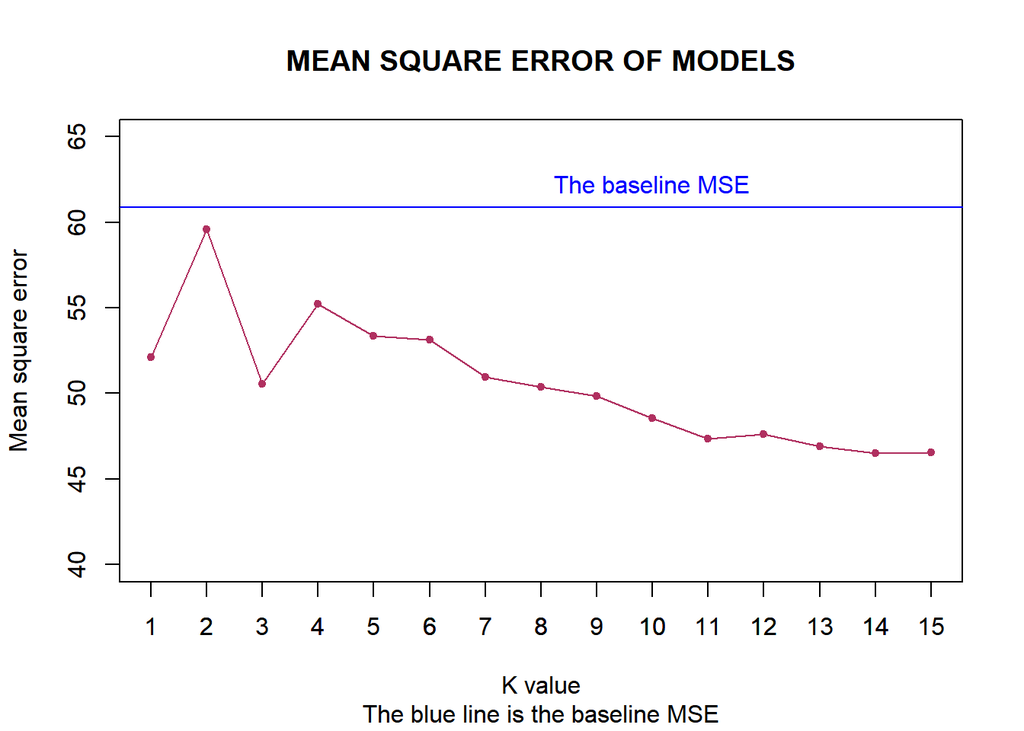

```r
plot(var_mse, type="o",
     col="maroon", pch=20, xlab="K value", ylab="Mean square error",
     ylim=c(40, 65),
     main="MEAN SQUARE ERROR OF MODELS", sub = "The blue line is the baseline MSE")
abline(h=mse(newdd_test$`Y house price of unit area`,
           lm_pred), col="blue")
text(x = 10,y = mse(newdd_test$`Y house price of unit area`,
                    lm_pred), labels = "The baseline MSE", col = "blue",
     pos = 3)
axis(1, at=1:15)
```

## THE SEQUENTIAL TRAINING UPDATES MODEL

Now, it would not be wise if we just follow the following steps below.

1. Use the trainind data, to fit a regression model
2. Use the model to predict the first test instance
3. Add the predicted test instance to the training data
4. Update the model with the new updated training dataset.

This is because , (assume the case of simple linear regression), predicted values are the values that literally lie on the regression line. Therefore, even if we predicted a test instance and added it to the training data, and then used the new training data to refit the model, NOTHING will change in the way the model behaves since, the predicted value from the test instance lies on the line, therefore even refitting the model, will produce the exact same model !

To counter this problem, i choose to follow the following steps.

1. Use the trainind data, to fit a regression model
2. Use the model to predict the first test instance
3. Add some “noise” to the predicted output
4. Add the “noise added” predicted test instance to the training data
5. Update the model with the new updated training dataset.

The noise i add to the predicted test instances, is noise obtained from the nearest neighbours of the test instance averaged.(This method is so efficient, i have been using it to improve MSE scores).

The following function below tackles that

```r
# additive lm models with noise addition

additive_lm <- function(formulae, train, test)
{
  # hold test results
  temp <- vector()

  for (i in 1:nrow(test))
  {
    print(paste("Total Training instances now are: ", nrow(train)))

    # the model
    regmod <- lm(formula = formulae, data=train)

    message(paste("Model fitting test instance: ",i))
    temp[i] <- predict.lm(regmod, test[i,], type = "response")

    # adding noise to predicted test instance
    nn_lm <- combine_knnlm(train = train[, -6],
                           test = test[i, ],
                           train_labs = train[, 6],
                           k=7) %>%
      unlist()

    #print("check nn_lm")
    #message(nn_lm)

    res_knnlm <- mean((regmod$residuals)[nn_lm], na.rm=T)
    w_noise <- temp[i] + res_knnlm
    #print(w_noise)

    #print("check end noise adds")

    temp[i] <- w_noise
    rm(w_noise)

    # continuation
    temp_testrow <- c(test[i, ], temp[i])
    names(temp_testrow) <- names(train)

    train <- rbind(train, temp_testrow)
    rm(temp_testrow)
  }
  return(temp)
}
```

Trying this function on the data:

```r
# trying it on real estate dataset
addnoise <- additive_lm(formulae = `Y house price of unit area`~
                          `X2 house age`+`X3 distance to the nearest MRT station`+
                          `X4 number of convenience stores`+`X5 latitude`, train = newdd_train, test = newdd_test[100:1, -6])
```

```
## [1] "Total Training instances now are:  314"
```

```
## Model fitting test instance:  1
```

```
## [1] "Total Training instances now are:  315"
```

```
## Model fitting test instance:  2
```

```
## [1] "Total Training instances now are:  316"
```

```
## Model fitting test instance:  3
```

```
## [1] "Total Training instances now are:  317"
```

```
## Model fitting test instance:  4
```

```
## [1] "Total Training instances now are:  318"
```

```
## Model fitting test instance:  5
```

```
## [1] "Total Training instances now are:  319"
```

```
## Model fitting test instance:  6
```

```
## [1] "Total Training instances now are:  320"
```

```
## Model fitting test instance:  7
```

```
## [1] "Total Training instances now are:  321"
```

```
## Model fitting test instance:  8
```

```
## [1] "Total Training instances now are:  322"
```

```
## Model fitting test instance:  9
```

```
## [1] "Total Training instances now are:  323"
```

```
## Model fitting test instance:  10
```

```
## [1] "Total Training instances now are:  324"
```

```
## Model fitting test instance:  11
```

```
## [1] "Total Training instances now are:  325"
```

```
## Model fitting test instance:  12
```

```
## [1] "Total Training instances now are:  326"
```

```
## Model fitting test instance:  13
```

```
## [1] "Total Training instances now are:  327"
```

```
## Model fitting test instance:  14
```

```
## [1] "Total Training instances now are:  328"
```

```
## Model fitting test instance:  15
```

```
## [1] "Total Training instances now are:  329"
```

```
## Model fitting test instance:  16
```

```
## [1] "Total Training instances now are:  330"
```

```
## Model fitting test instance:  17
```

```
## [1] "Total Training instances now are:  331"
```

```
## Model fitting test instance:  18
```

```
## [1] "Total Training instances now are:  332"
```

```
## Model fitting test instance:  19
```

```
## [1] "Total Training instances now are:  333"
```

```
## Model fitting test instance:  20
```

```
## [1] "Total Training instances now are:  334"
```

```
## Model fitting test instance:  21
```

```
## [1] "Total Training instances now are:  335"
```

```
## Model fitting test instance:  22
```

```
## [1] "Total Training instances now are:  336"
```

```
## Model fitting test instance:  23
```

```
## [1] "Total Training instances now are:  337"
```

```
## Model fitting test instance:  24
```

```
## [1] "Total Training instances now are:  338"
```

```
## Model fitting test instance:  25
```

```
## [1] "Total Training instances now are:  339"
```

```
## Model fitting test instance:  26
```

```
## [1] "Total Training instances now are:  340"
```

```
## Model fitting test instance:  27
```

```
## [1] "Total Training instances now are:  341"
```

```
## Model fitting test instance:  28
```

```
## [1] "Total Training instances now are:  342"
```

```
## Model fitting test instance:  29
```

```
## [1] "Total Training instances now are:  343"
```

```
## Model fitting test instance:  30
```

```
## [1] "Total Training instances now are:  344"
```

```
## Model fitting test instance:  31
```

```
## [1] "Total Training instances now are:  345"
```

```
## Model fitting test instance:  32
```

```
## [1] "Total Training instances now are:  346"
```

```
## Model fitting test instance:  33
```

```
## [1] "Total Training instances now are:  347"
```

```
## Model fitting test instance:  34
```

```
## [1] "Total Training instances now are:  348"
```

```
## Model fitting test instance:  35
```

```
## [1] "Total Training instances now are:  349"
```

```
## Model fitting test instance:  36
```

```
## [1] "Total Training instances now are:  350"
```

```
## Model fitting test instance:  37
```

```
## [1] "Total Training instances now are:  351"
```

```
## Model fitting test instance:  38
```

```
## [1] "Total Training instances now are:  352"
```

```
## Model fitting test instance:  39
```

```
## [1] "Total Training instances now are:  353"
```

```
## Model fitting test instance:  40
```

```
## [1] "Total Training instances now are:  354"
```

```
## Model fitting test instance:  41
```

```
## [1] "Total Training instances now are:  355"
```

```
## Model fitting test instance:  42
```

```
## [1] "Total Training instances now are:  356"
```

```
## Model fitting test instance:  43
```

```
## [1] "Total Training instances now are:  357"
```

```
## Model fitting test instance:  44
```

```
## [1] "Total Training instances now are:  358"
```

```
## Model fitting test instance:  45
```

```
## [1] "Total Training instances now are:  359"
```

```
## Model fitting test instance:  46
```

```
## [1] "Total Training instances now are:  360"
```

```
## Model fitting test instance:  47
```

```
## [1] "Total Training instances now are:  361"
```

```
## Model fitting test instance:  48
```

```
## [1] "Total Training instances now are:  362"
```

```
## Model fitting test instance:  49
```

```
## [1] "Total Training instances now are:  363"
```

```
## Model fitting test instance:  50
```

```
## [1] "Total Training instances now are:  364"
```

```
## Model fitting test instance:  51
```

```
## [1] "Total Training instances now are:  365"
```

```
## Model fitting test instance:  52
```

```
## [1] "Total Training instances now are:  366"
```

```
## Model fitting test instance:  53
```

```
## [1] "Total Training instances now are:  367"
```

```
## Model fitting test instance:  54
```

```
## [1] "Total Training instances now are:  368"
```

```
## Model fitting test instance:  55
```

```
## [1] "Total Training instances now are:  369"
```

```
## Model fitting test instance:  56
```

```
## [1] "Total Training instances now are:  370"
```

```
## Model fitting test instance:  57
```

```
## [1] "Total Training instances now are:  371"
```

```
## Model fitting test instance:  58
```

```
## [1] "Total Training instances now are:  372"
```

```
## Model fitting test instance:  59
```

```
## [1] "Total Training instances now are:  373"
```

```
## Model fitting test instance:  60
```

```
## [1] "Total Training instances now are:  374"
```

```
## Model fitting test instance:  61
```

```
## [1] "Total Training instances now are:  375"
```

```
## Model fitting test instance:  62
```

```
## [1] "Total Training instances now are:  376"
```

```
## Model fitting test instance:  63
```

```
## [1] "Total Training instances now are:  377"
```

```
## Model fitting test instance:  64
```

```
## [1] "Total Training instances now are:  378"
```

```
## Model fitting test instance:  65
```

```
## [1] "Total Training instances now are:  379"
```

```
## Model fitting test instance:  66
```

```
## [1] "Total Training instances now are:  380"
```

```
## Model fitting test instance:  67
```

```
## [1] "Total Training instances now are:  381"
```

```
## Model fitting test instance:  68
```

```
## [1] "Total Training instances now are:  382"
```

```
## Model fitting test instance:  69
```

```
## [1] "Total Training instances now are:  383"
```

```
## Model fitting test instance:  70
```

```
## [1] "Total Training instances now are:  384"
```

```
## Model fitting test instance:  71
```

```
## [1] "Total Training instances now are:  385"
```

```
## Model fitting test instance:  72
```

```
## [1] "Total Training instances now are:  386"
```

```
## Model fitting test instance:  73
```

```
## [1] "Total Training instances now are:  387"
```

```
## Model fitting test instance:  74
```

```
## [1] "Total Training instances now are:  388"
```

```
## Model fitting test instance:  75
```

```
## [1] "Total Training instances now are:  389"
```

```
## Model fitting test instance:  76
```

```
## [1] "Total Training instances now are:  390"
```

```
## Model fitting test instance:  77
```

```
## [1] "Total Training instances now are:  391"
```

```
## Model fitting test instance:  78
```

```
## [1] "Total Training instances now are:  392"
```

```
## Model fitting test instance:  79
```

```
## [1] "Total Training instances now are:  393"
```

```
## Model fitting test instance:  80
```

```
## [1] "Total Training instances now are:  394"
```

```
## Model fitting test instance:  81
```

```
## [1] "Total Training instances now are:  395"
```

```
## Model fitting test instance:  82
```

```
## [1] "Total Training instances now are:  396"
```

```
## Model fitting test instance:  83
```

```
## [1] "Total Training instances now are:  397"
```

```
## Model fitting test instance:  84
```

```
## [1] "Total Training instances now are:  398"
```

```
## Model fitting test instance:  85
```

```
## [1] "Total Training instances now are:  399"
```

```
## Model fitting test instance:  86
```

```
## [1] "Total Training instances now are:  400"
```

```
## Model fitting test instance:  87
```

```
## [1] "Total Training instances now are:  401"
```

```
## Model fitting test instance:  88
```

```
## [1] "Total Training instances now are:  402"
```

```
## Model fitting test instance:  89
```

```
## [1] "Total Training instances now are:  403"
```

```
## Model fitting test instance:  90
```

```
## [1] "Total Training instances now are:  404"
```

```
## Model fitting test instance:  91
```

```
## [1] "Total Training instances now are:  405"
```

```
## Model fitting test instance:  92
```

```
## [1] "Total Training instances now are:  406"
```

```
## Model fitting test instance:  93
```

```
## [1] "Total Training instances now are:  407"
```

```
## Model fitting test instance:  94
```

```
## [1] "Total Training instances now are:  408"
```

```
## Model fitting test instance:  95
```

```
## [1] "Total Training instances now are:  409"
```

```
## Model fitting test instance:  96
```

```
## [1] "Total Training instances now are:  410"
```

```
## Model fitting test instance:  97
```

```
## [1] "Total Training instances now are:  411"
```

```
## Model fitting test instance:  98
```

```
## [1] "Total Training instances now are:  412"
```

```
## Model fitting test instance:  99
```

```
## [1] "Total Training instances now are:  413"
```

```
## Model fitting test instance:  100
```

```r
mse(addnoise, newdd_test[100:1, 6])
```

```
## [1] 53.03813
```

The mean squared error obtained is 53

I expected that by adding more data while training, there would be higher chances of improving prediction accuracy, which is not the case !

Or is something wrong with my analysis ? Thanks a lot.